# 11차 빅데이터 분석 II 및 시각화

## 프로젝트 개요

- 강의명 : (산대특)_공공데이터 활용 빅데이터 분석 및 시각화 전문가 과정 육성
- 교과목명 : 빅데이터 분석 II 및 시각화
- 프로젝트 주제 : tidymodels 라이브러리 및 Sale Price 데이터를 활용한 시각화 및 머신러닝 모델 개발
- 프로젝트 마감일 : 2022년 12월 19일
- 수강생명 : 김도위

## 평가 1. 라이브러리 불러오기 (5점)

- 주요 라이브러리 및 설치 불러오는 코드를 작성한다.

```r
# install.packages('tidymodels')
library(tidymodels)
```

## 평가 2. 데이터 불러오기 (5점)

- sale_price 데이터를 불러온다.
- head() 함수를 활용하여 데이터를 개괄적으로 보여주도록 한다.

```r
data("ames")
head(ames)
```

| MS_SubClass | MS_Zoning | Lot_Frontage | Lot_Area | Street | Alley | Lot_Shape | Land_Contour | Utilities | Lot_Config | Land_Slope | Neighborhood | Condition_1 | Condition_2 | Bldg_Type | House_Style | Overall_Cond | Year_Built | Year_Remod_Add | Roof_Style | Roof_Matl | Exterior_1st | Exterior_2nd | Mas_Vnr_Type | Mas_Vnr_Area | Exter_Cond | Foundation | Bsmt_Cond | Bsmt_Exposure | BsmtFin_Type_1 | … |
| --- | --- | --- | --- | --- | --- | --- | --- | --- | --- | --- | --- | --- | --- | --- | --- | --- | --- | --- | --- | --- | --- | --- | --- | --- | --- | --- | --- | --- | --- | --- |
| One_Story_1946_and_Newer_All_Styles | Residential_Low_Density | 141 | 31770 | Pave | No_Alley_Access | Slightly_Irregular | Lvl | AllPub | Corner | Gtl | North_Ames | Norm | Norm | OneFam | One_Story | Average | 1960 | 1960 | Hip | CompShg | BrkFace | Plywood | Stone | 112 | Typical | CBlock | Good | Gd | BLQ | … |
| One_Story_1946_and_Newer_All_Styles | Residential_High_Density | 80 | 11622 | Pave | No_Alley_Access | Regular | Lvl | AllPub | Inside | Gtl | North_Ames | Feedr | Norm | OneFam | One_Story | Above_Average | 1961 | 1961 | Gable | CompShg | VinylSd | VinylSd | None | 0 | Typical | CBlock | Typical | No | Rec | … |
| One_Story_1946_and_Newer_All_Styles | Residential_Low_Density | 81 | 14267 | Pave | No_Alley_Access | Slightly_Irregular | Lvl | AllPub | Corner | Gtl | North_Ames | Norm | Norm | OneFam | One_Story | Above_Average | 1958 | 1958 | Hip | CompShg | Wd Sdng | Wd Sdng | BrkFace | 108 | Typical | CBlock | Typical | No | ALQ | … |
| One_Story_1946_and_Newer_All_Styles | Residential_Low_Density | 93 | 11160 | Pave | No_Alley_Access | Regular | Lvl | AllPub | Corner | Gtl | North_Ames | Norm | Norm | OneFam | One_Story | Average | 1968 | 1968 | Hip | CompShg | BrkFace | BrkFace | None | 0 | Typical | CBlock | Typical | No | ALQ | … |
| Two_Story_1946_and_Newer | Residential_Low_Density | 74 | 13830 | Pave | No_Alley_Access | Slightly_Irregular | Lvl | AllPub | Inside | Gtl | Gilbert | Norm | Norm | OneFam | Two_Story | Average | 1997 | 1998 | Gable | CompShg | VinylSd | VinylSd | None | 0 | Typical | PConc | Typical | No | GLQ | … |
| Two_Story_1946_and_Newer | Residential_Low_Density | 78 | 9978 | Pave | No_Alley_Access | Slightly_Irregular | Lvl | AllPub | Inside | Gtl | Gilbert | Norm | Norm | OneFam | Two_Story | Above_Average | 1998 | 1998 | Gable | CompShg | VinylSd | VinylSd | BrkFace | 20 | Typical | PConc | Typical | No | GLQ | … |

## 평가 3. 데이터 시각화 (50점)

- 시각화 종류에 관계없이 시각화 10개를 작성한다.
- 평가기준
  - 10개 작성 : 50점
  - 7개 작성 : 35점
  - 5개 작성 : 25점
  - 3개 작성 : 15점
- 참고자료
  - URL : http://r-statistics.co/Complete-Ggplot2-Tutorial-Part1-With-R-Code.html

### (1) 산점도그래프

- Lot_Area 기준으로 Sale_Price 산점도 작성함.
- 대부분의 Sale_Condition 값들은 50000 값 이하에 몰려 있지만 그 이상의 값(이상치)은 대부분 Normal 형태를 취하고 있는 것을 알 수 있다.

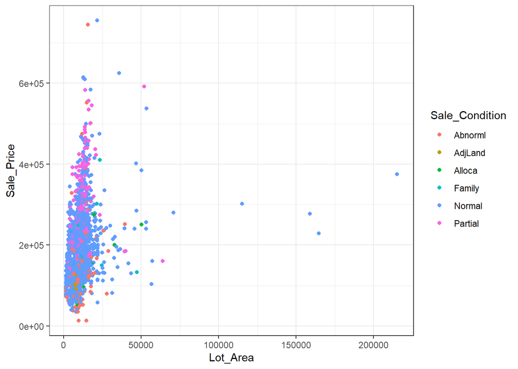

```r
ggplot(ames, aes(x = Lot_Area,
                 y = Sale_Price,
                 color = Sale_Condition)) +
  geom_point() +
  theme_bw()
```

### (2) Scatterplot그래프

- Garage_Area 를 기준으로 Sale_Price 그래프 작성함.
- Garage_Area 값들의 대부분은 중간값 아래로 형성되어 있다. Garage_Area 값이 커질수록 Sale_Price 값이 증가하는 것을 선을 통해 알 수 있지만 증가값의 폭이 크지 않다는 것을 알 수 있다. 또한 Garage_Area 값이 1250 을 넘어갈 때는 오히려 Sale_Price 값이 줄어드는 것을 알 수 있다.

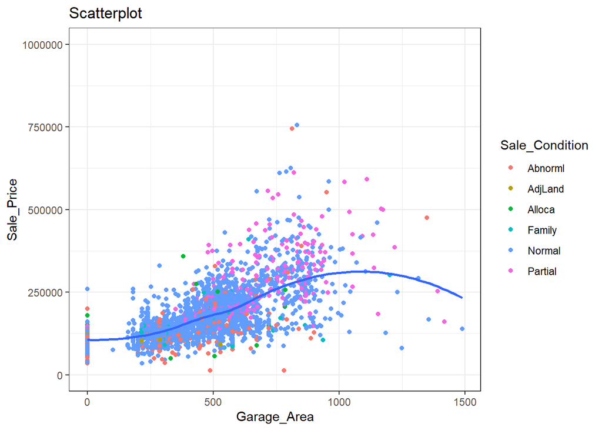

```r
ggplot(ames, aes(x=Garage_Area, y=Sale_Price)) +
  geom_point(aes(col=Sale_Condition)) +
  geom_smooth(method="loess", se=F) +
  ylim(c(0, 1000000)) +
  labs(y="Sale_Price",
       x="Garage_Area",
       title="Scatterplot") +
  theme_bw()
```

### (3) Jitterplot 그래프

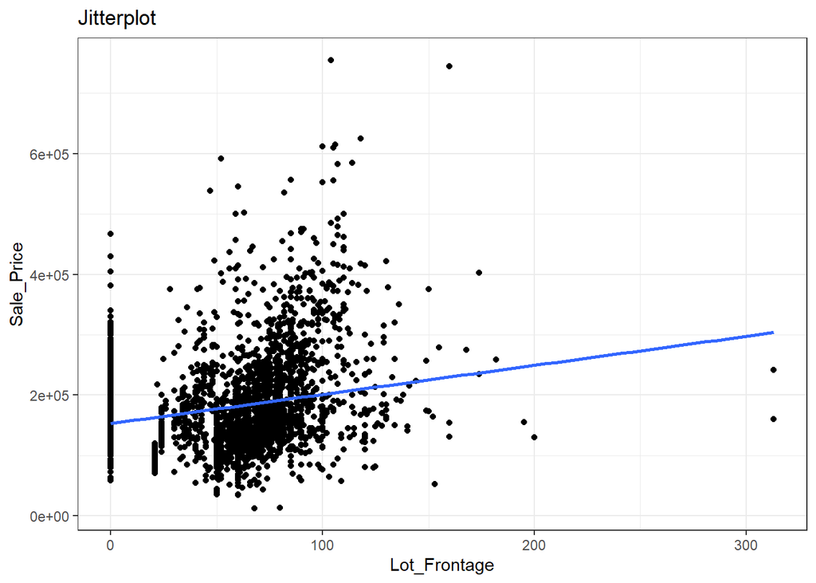

```r
ggplot(ames, aes(Lot_Frontage, Sale_Price)) + geom_point() +
  geom_smooth(method="lm", se=F) +
  labs(y="Sale_Price",
       x="Lot_Frontage",
       title="Jitterplot") +
    theme_bw()
```

### (4) 막대 그래프

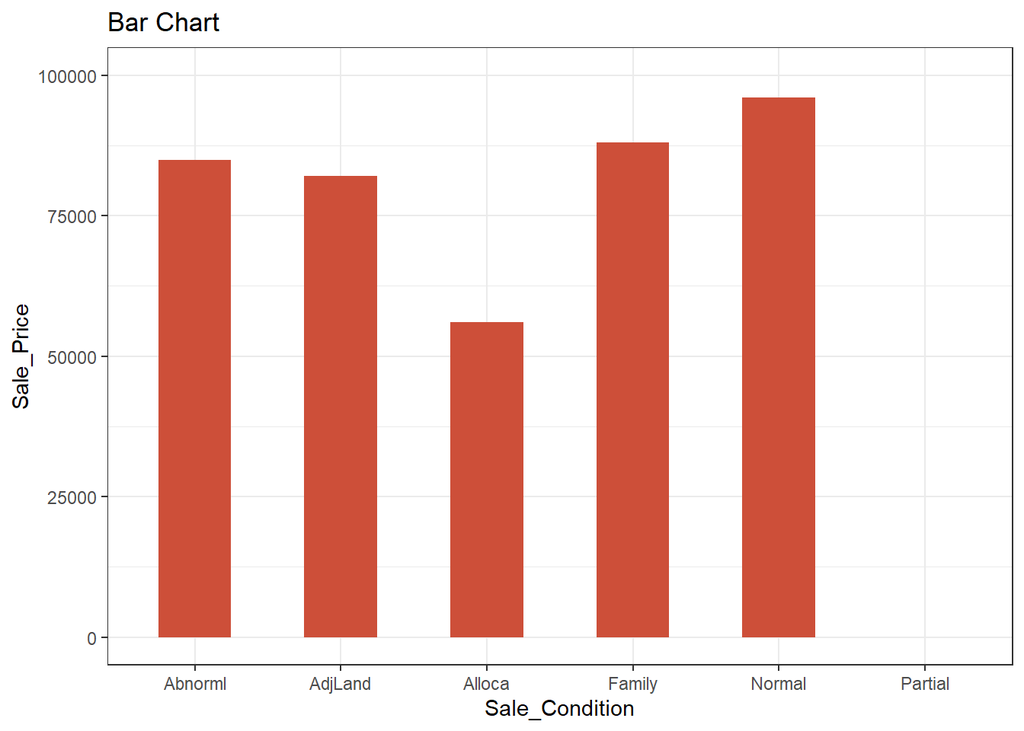

```r
ggplot(ames, aes(x=Sale_Condition, y=Sale_Price)) +
  geom_bar(stat="identity", width=.5, fill="tomato3") +
  labs(title = "Bar Chart") +
  ylim(c(0, 100000))  +
  theme_bw()
```

### (5) 영역 그래프

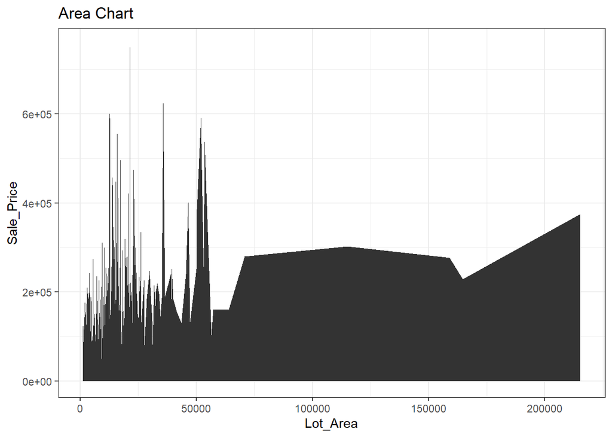

```r
ggplot(ames, aes(x=Lot_Area, y=Sale_Price)) +
  geom_area() +
  labs(title = "Area Chart") +
  theme_bw()
```

### (6) 히스토그램 그래프

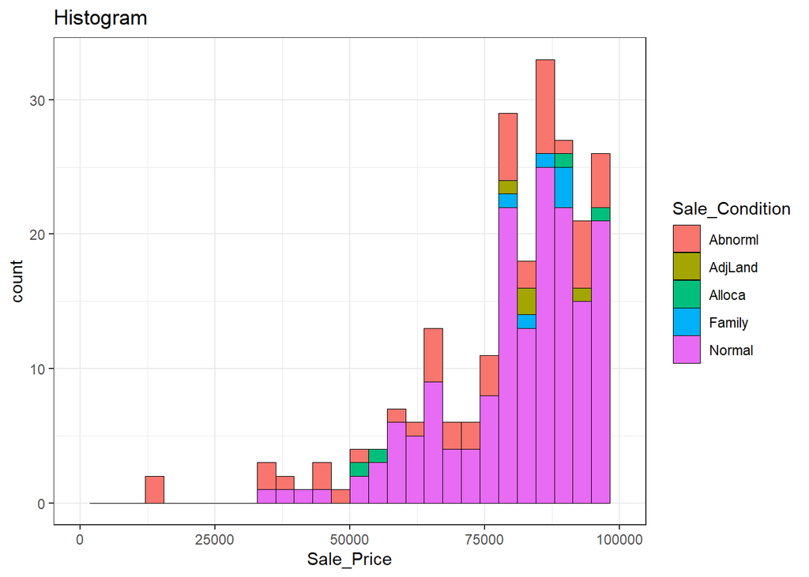

```r
ggplot(ames, aes(x=Sale_Price)) +
  geom_histogram(aes(fill=Sale_Condition),
                 col="black",
                 size=.1) +
  labs(title="Histogram") +
  xlim(c(0,100000)) +
  theme_bw()
```

### (7) 밀도 그래프

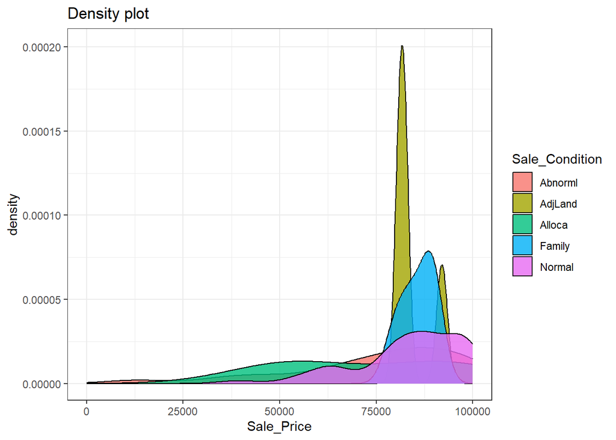

```r
ggplot(ames, aes(x=Sale_Price)) +
  geom_density(aes(fill=Sale_Condition), alpha=0.8) +
  labs(title="Density plot") +
  xlim(c(0,100000)) +
  theme_bw()
```

### (8) 빈도 다각형 그래프

- Garage_Cond 별, Garage_Area 를 기준으로 빈도 다각형 그래프를 작성함.
- 대부분의 Garage_Area 값은 약 500에 몰려 있으며, 그 형태 또한 대부분 Typical이다. Garage_Area 값이 클수록 오히려 모든 부분에서 count 값이 줄어드는 것을 알 수 있다. 1순위는 Typical 이지만 2순위가 No_Garage인 것을 알 수 있다.

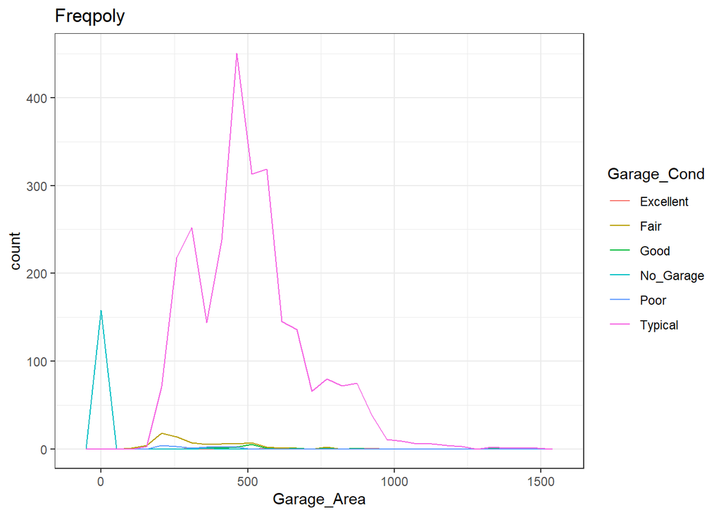

```r
ggplot(ames, aes(x=Garage_Area)) +
  geom_freqpoly(aes(color=Garage_Cond), position = "identity") +
  theme_bw() +
  labs(title = "Freqpoly")
```

### (9) Treemap 그래프

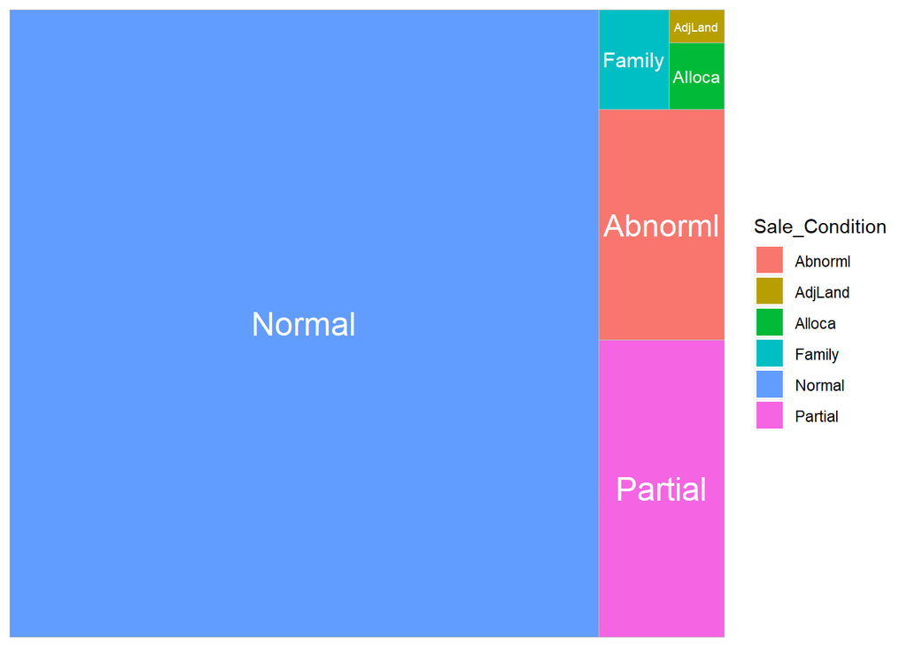

```r
library(treemapify)
plotdata = ames %>%
  count(Sale_Condition)
ggplot(plotdata, aes(fill=Sale_Condition, area = n,
                     label=Sale_Condition)) +
  geom_treemap() +
  geom_treemap_text(colour="white",
                    place = "center")
```

### (10) 능선형 그래프

- Garage_Cond 별, Garage_Area를 기준으로 그래프를 작성함.
- 각 Garage_Cond 별로 Garage_Area 값을 확인할 수 있다. Poor과 Fair 값의 경우에는 Garage_Area가 약 250에 값이 최고값을 가진 것을 알 수 있다. Typical 과 Good 값은 약 500 값에 최고값을 가진다. Excellent 값은 특이하게도 약 200부터 약 1100 값까지 물결 형태를 보여주고 있다. 이를 통해 Excellent는 특정 값과 기준으로 구성되어 있음을 알 수 있다.

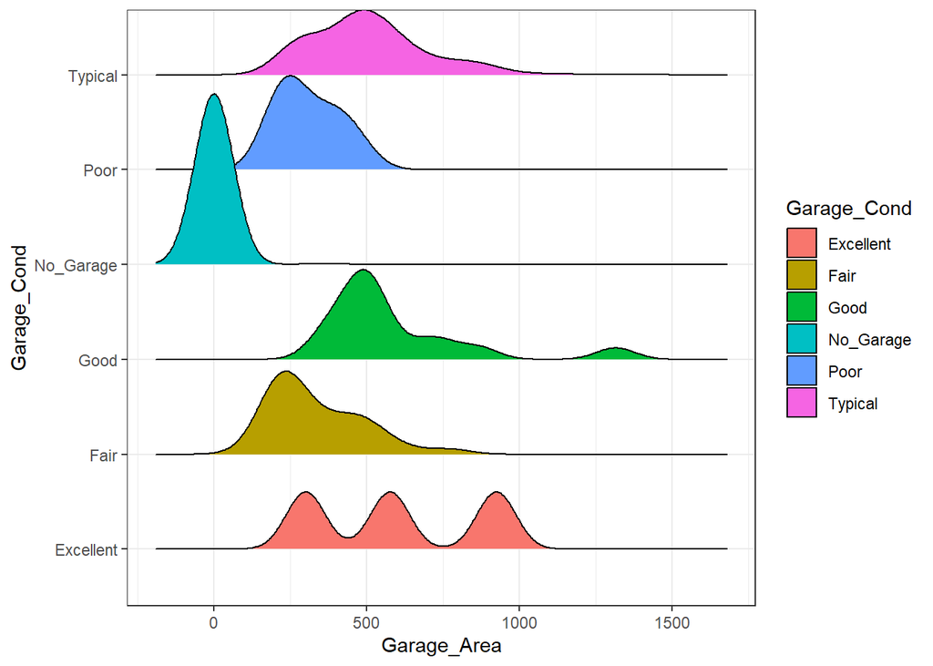

```r
library(ggridges)
ggplot(ames,aes(x=Garage_Area, y=Garage_Cond, fill=Garage_Cond)) +
  geom_density_ridges() +
  theme_ridges() +
  labs("Ridgeline plots") +
  theme_bw()
```

### (11) 바이올린 그래프

- Lot_Config 별, Lot_Area 기준으로 그래프 작성함.
- 대부분의 Lot_Config 값은 0에서 25,000 값 사이에 몰려 있는 것을 알 수 있다. 이 중 Corner, CulDSac, Inside 값은 높은 Lot_Area 값을 가지고 있는 것을 확인할 수 있다. 1순위는 Inside, 2순위는 Corner, 3순위는 CulDSac임을 알 수 있다.

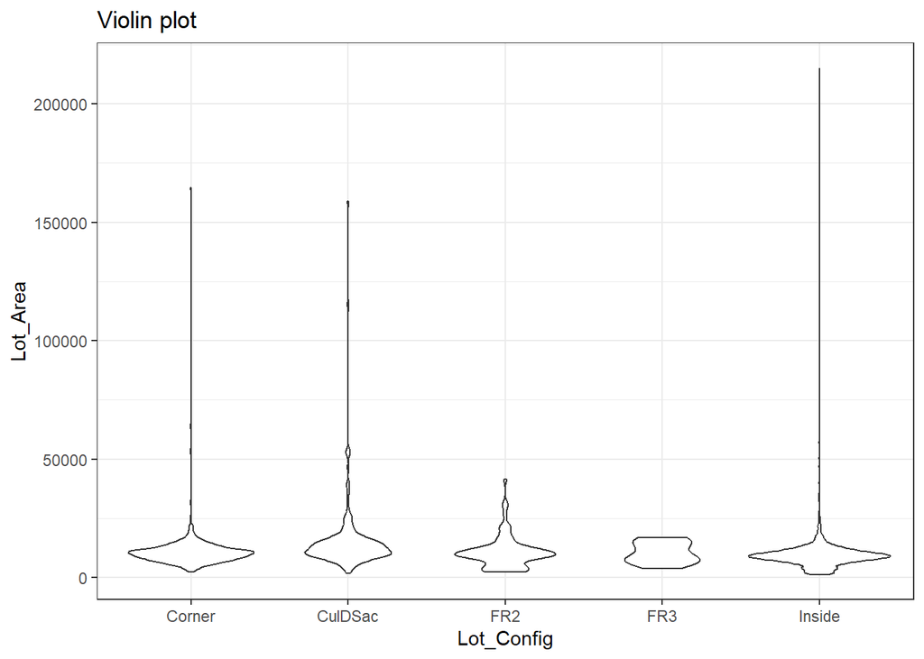

```r
ggplot(ames, aes(x=Lot_Config, y=Lot_Area)) +
  geom_violin() +
  labs(title = "Violin plot") +
  theme_bw()
```

## 평가 4. 요약 통계 구하기 (10점)

- Sale_Price가 500000 이상인 데이터 중에서 Pool_QC에 따른 평균 Sale_Price 값을 구한다.

```r
# 코드
ames %>%
  filter(Sale_Price >= 500000) %>%
  group_by(Pool_QC) %>%
  summarise(avg_Sale_Price = mean(Sale_Price))
```

| Pool_QC | avg_Sale_Price |
| --- | --- |
| Excellent | 680000.0 |
| No_Pool | 571524.1 |

## 평가 5. 머신러닝 모델링 (20점)

- 주어진 규칙에 따라 머신러닝 코드를 작성한다.
  - `8:2` 비율로 훈련데이터셋 및 테스트데이터셋으로 분리한다. (5점)
  - 모델링은 `RandomForest`와 `glmnet` 알고리즘을 활용한다. (10점)
    - 만약 1개만 사용 시 5점만 부여
  - feature Engineering 코드는 주어진 코드이기 때문에 그대로 활용한다.
- 옵션: 필요 시, 라이브러리 설치를 한다.
  - `install.packages(c('ranger', 'glmnet'))`
- Sale_Price와 각 모델의 예측 결과표를 만든다. (5점)

### (1) 훈련/테스트 데이터셋 만들기

- `8:2` 비율로 훈련데이터셋 및 테스트데이터셋으로 분리한다. (5점)

```r
set.seed(42)

Mutation_split = initial_split(ames, strata = 'Sale_Price', prop = 0.8)

Mt_train = training(Mutation_split)
Mt_test = testing(Mutation_split)

# 다음 코드는 예시다
Mt_recipe = recipe(
    Sale_Price ~ Longitude + Latitude + Lot_Area + Neighborhood + Year_Sold,
    data = Mt_train
  ) %>%
  step_other(Neighborhood) %>%
  step_dummy(all_nominal()) %>%
  step_center(all_predictors()) %>%
  step_scale(all_predictors()) %>%
  step_log(Sale_Price, base = 10) %>%

  prep(training = Mt_train, retain = TRUE)

Mt_test_normalized <- bake(Mt_recipe, new_data = Mt_test,
                        all_predictors())
```

### (2) RandomForest

- RandomForest 모형을 작성 후, 확인한다.

```r
# Random Forest
Mt_rf_fit = rand_forest(mode = "regression", mtry = .preds(), trees = 700) %>%
  set_engine("ranger") %>%
  fit(
    Sale_Price ~ ., data = bake(Mt_recipe, new_data = NULL)
  )

Mt_rf_fit
```

```
## parsnip model object
##
## Ranger result
##
## Call:
##  ranger::ranger(x = maybe_data_frame(x), y = y, mtry = min_cols(~.preds(),      x), num.trees = ~700, num.threads = 1, verbose = FALSE, seed = sample.int(10^5,      1))
##
## Type:                             Regression
## Number of trees:                  700
## Sample size:                      2342
## Number of independent variables:  12
## Mtry:                             12
## Target node size:                 5
## Variable importance mode:         none
## Splitrule:                        variance
## OOB prediction error (MSE):       0.00923702
## R squared (OOB):                  0.7110353
```

### (3) glmnet

- glmnet 모형을 작성 후, 확인한다.

```r
# glmnet
Mt_gl_fit = linear_reg(penalty = 0.001, mixture = 0.3) %>%
  set_engine("glmnet") %>%
  fit(Sale_Price ~ ., data = bake(Mt_recipe, new_data = NULL))

Mt_gl_fit
```

```
## parsnip model object
##
##
## Call:  glmnet::glmnet(x = maybe_matrix(x), y = y, family = "gaussian",      alpha = ~0.3)
##
##    Df  %Dev   Lambda
## 1   0  0.00 0.222900
## 2   1  1.35 0.203100
## 3   1  2.62 0.185000
## 4   2  3.87 0.168600
## 5   3  5.85 0.153600
## 6   4  8.29 0.140000
## 7   5 11.05 0.127500
## 8   5 13.58 0.116200
## 9   7 16.39 0.105900
```

[output cut: 58 more lines]

### (4) 예측 결과표 만들기

- Sale_Price 컬럼과 예측 모델 결과표를 합한 새로운 데이터 프레임이다.

```r
Mt_test_normalized <- bake(Mt_recipe, new_data = Mt_test, all_predictors())

Mt_test_results <- Mt_test  %>%
  select(Sale_Price) %>%
  mutate(Sale_Price = log10(Sale_Price)) %>%
  bind_cols(
    predict(Mt_rf_fit, new_data = Mt_test_normalized) %>%
      rename(randomForest = .pred)
    , predict(Mt_gl_fit, new_data = Mt_test_normalized) %>%
      rename(glmnet = .pred)
  )

Mt_test_results
```

| Sale_Price | randomForest | glmnet |
| --- | --- | --- |
| 5.021189 | 5.237839 | 5.170455 |
| 5.235528 | 5.307009 | 5.181606 |
| 5.595972 | 5.488999 | 5.246929 |
| 5.152288 | 5.186521 | 5.175793 |
| 5.264818 | 5.147754 | 5.155542 |
| 4.982271 | 5.021265 | 5.188234 |
| 5.023252 | 5.029160 | 5.188504 |
| 4.944483 | 4.997778 | 5.188028 |
| 5.175802 | 5.122066 | 5.186815 |
| 5.698970 | 5.639262 | 5.494339 |

[output cut: 578 more lines]

## 평가 6. 두개의 모형 비교 (10점)

- 회귀모형 평가지표를 활용하여 예측 지표를 작성한다. (5점)

```r
results_left = Mt_test_results %>%
  metrics(truth = Sale_Price, estimate = randomForest) %>%
  mutate(model = 'randomForest')

results_right = Mt_test_results %>%
  metrics(truth = Sale_Price, estimate = glmnet) %>%
  mutate(model = 'glmnet')

bind_rows(results_left, results_right)
```

| .metric | .estimator | .estimate | model |
| --- | --- | --- | --- |
| rmse | standard | 0.08606477 | randomForest |
| rsq | standard | 0.74752685 | randomForest |
| mae | standard | 0.06484455 | randomForest |
| rmse | standard | 0.12820733 | glmnet |
| rsq | standard | 0.43476450 | glmnet |
| mae | standard | 0.09538380 | glmnet |

- 두개의 그래프를 비교하는 코드를 작성한다. (5점)

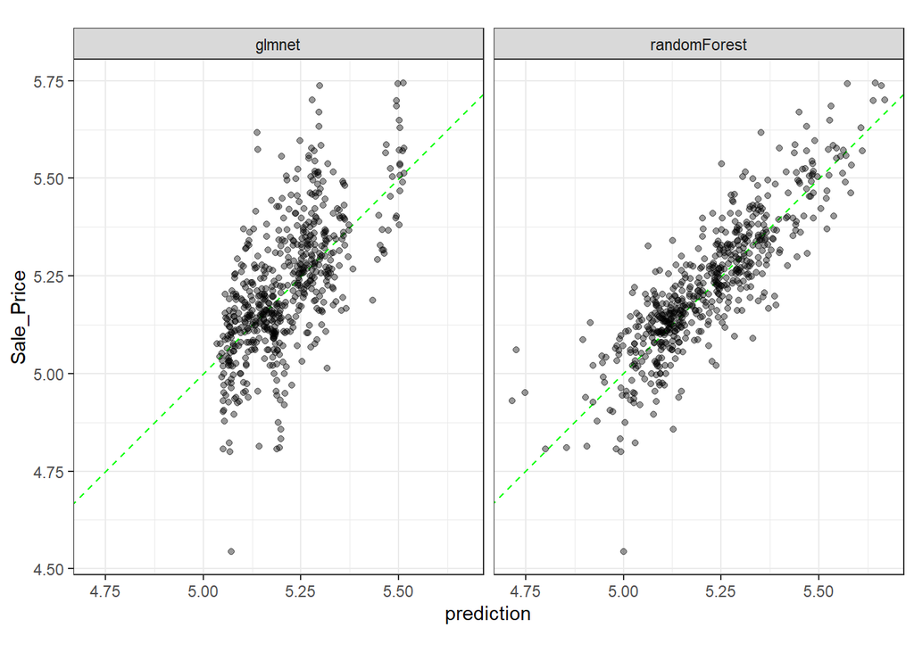

```r
Mt_test_results %>%
  gather(model, prediction, -Sale_Price) %>%
  ggplot(aes(x = prediction, y = Sale_Price)) +
  geom_abline(col = "green", lty = 2) +
  geom_point(alpha = .4) +
  facet_wrap(~model) +
  coord_fixed() +
  theme_bw()
```